# imbh_diagnosis-Copy1

```python
from IPython.display import HTML

HTML('''<script>
code_show=true;
function code_toggle() {
 if (code_show){
 $('div.input').hide();
 } else {
 $('div.input').show();
 }
 code_show = !code_show
}
$( document ).ready(code_toggle);
</script>
<form action="javascript:code_toggle()"><input type="submit" value="Click here to toggle on/off the raw code."></form>''')
```

Here we check the effects of an IMBH on S2's orbital elements (particularly $\bar{\omega}$) with direct N--body simulations. These simulations include GR effects, and are run for a single orbital period of S2 (~16 years)

We expect $\bar{\omega}$ to change by $1.1\times 10^{-2}$ degrees per year due to GR effects alone. This is in fact what we see in simulations without any IMBH, as shown in the plot of $\bar{\omega}$ versus time below. Note the two number at the top of the plot are the orbit averaged rates of change of $\arccos({\hat{j} \cdot \hat{z}})$* and $\bar{\omega}$.

*That is: the angle between the orbit's angular momentum vector and the z--axis.

```
No handles with labels found to put in legend.
```

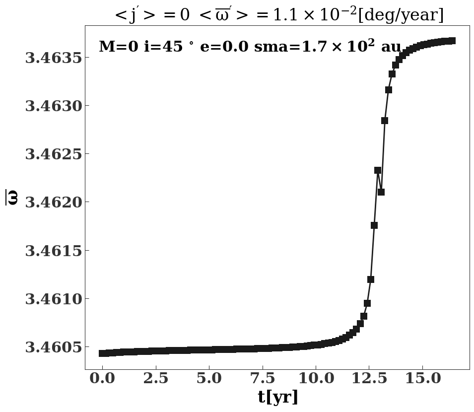

```python
%pylab inline
import numpy as np
import rebound
import reboundx
import cgs_const as cgs

from bash_command import bash_command as bc
import sys
from latex_exp import latex_exp

mm=0.0
inc=np.pi/4.
aa=170.*cgs.au/cgs.pc
ecc=0.
a1=1020*cgs.au/cgs.pc
P1=2.*np.pi*(a1)**1.5/(4.0e6)**0.5
e1=0.88


sim=rebound.Simulation()
rebx = reboundx.Extras(sim)
gr=rebx.add("gr")
gr.params["c"]=4571304.57795483
sim.move_to_com()

sim.G=1.0
sim.add(m=4e6)
sim.add(m=mm, a=aa, e=ecc, inc=inc, Omega=inc, M=np.random.uniform(0., 2.*np.pi), primary=sim.particles[0])
sim.add(a=a1, e=e1, pomega=np.random.uniform(0., 2.*np.pi), M=np.random.uniform(0., 2.*np.pi), primary=sim.particles[0])

with open('s2_check', 'w') as ff:
    for i in range(100):
        sim.move_to_com()
        orbs=sim.calculate_orbits(primary=sim.particles[0])
        oo=orbs[-1]
        j=np.cross(sim.particles[2].xyz, sim.particles[2].vxyz)
        j=j/np.linalg.norm(j)
        ff.write('{0} {1} {2} {3} {4} {5} {6}\n'.format(oo.a, oo.e, oo.inc, oo.Omega, oo.omega, oo.M, np.arccos(np.dot(j, [0,0,1]))))
        sim.integrate(sim.t+0.01*P1)

s2_dat=np.genfromtxt('s2_check')
po_dat=fmod(s2_dat[:,4]+s2_dat[:,3]+2.*np.pi, 2.*np.pi)
j_dat=s2_dat[:,-1]

fig,ax=plt.subplots(figsize=(10,9))
ts=np.linspace(0,1,100)*P1*1.5e7
ax.plot(ts, fmod(s2_dat[:,4]+s2_dat[:,3]+2.*np.pi, 2.*np.pi), 's-')
ax.set_ylabel(r"$\overline{\omega}$")
ax.set_xlabel(r"$t [yr]$")

t1=r"$<j'> =$"+"{0}".format(latex_exp.latex_exp((j_dat[-1]-j_dat[0])*180./np.pi/(P1*1.5e7)))
t2=r"$<\overline{\omega}'>=$"+"{0}".format(latex_exp.latex_exp((po_dat[-1]-po_dat[0])*180./np.pi/(P1*1.5e7)))+r"$[deg/year]$"
ax.set_title(t1+" "+t2)
ax.legend(loc='upper left',\
          title="M={0} i={1} e={2} sma={3} au".format(latex_exp.latex_exp(mm), "{0:1.0f}".format(inc*180./np.pi)+r" $^{\circ}$", ecc,\
                                                      latex_exp.latex_exp(aa*cgs.pc/cgs.au)))
```

Now we include a $10^3 M_{\odot}$ IMBH with a semi--major axis of 2000 au (~0.01 pc). For ease of comparison with Naoz et al. 2019 we consider a circular IMBH with $i=\Omega=\pi/4$. Based on Fig. 3 of that paper such an IMBH would be ruled out for causing $\overline{\omega}$ to change by more than $\sim$0.07 degrees/year. However, in our N--body simulations the perturbative effect of the IMBH is actually much weaker (in fact the precession is virtually indistinguishable from the GR--only case!) In fact, it seems possible to have an IMBH with a mass up to a few $\times 10^4 M_{\odot}$ at this semi--major axis. (Higher mass IMBHs can be ruled out since they would cause too much precession of the angular momentum vector).

```
No handles with labels found to put in legend.
```

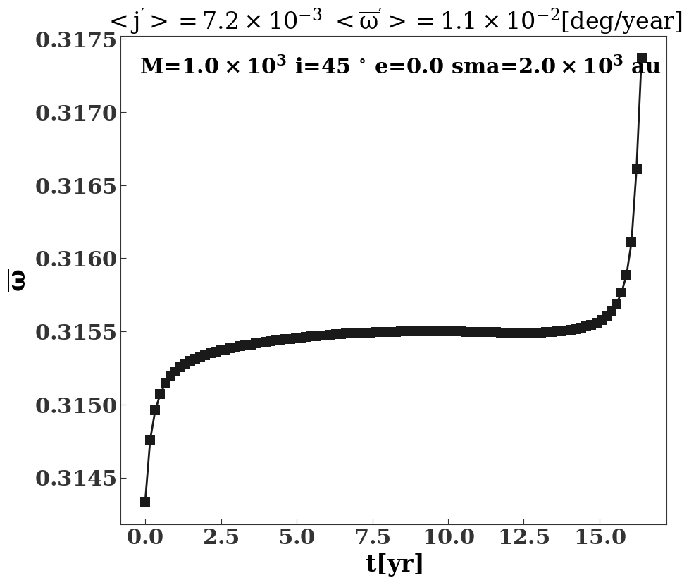

```python
%pylab inline
import numpy as np
import rebound
import reboundx
import cgs_const as cgs

from bash_command import bash_command as bc
import sys
from latex_exp import latex_exp

mm=1e3
inc=np.pi/4.
aa=2000.*cgs.au/cgs.pc
ecc=0.
a1=1020*cgs.au/cgs.pc
P1=2.*np.pi*(a1)**1.5/(4.0e6)**0.5
e1=0.88


sim=rebound.Simulation()
rebx = reboundx.Extras(sim)
gr=rebx.add("gr")
gr.params["c"]=4571304.57795483
sim.move_to_com()

sim.G=1.0
sim.add(m=4e6)
sim.add(m=mm, a=aa, e=ecc, inc=inc, Omega=inc, M=np.random.uniform(0., 2.*np.pi), primary=sim.particles[0])
sim.add(a=a1, e=e1, pomega=np.random.uniform(0., 2.*np.pi), M=np.random.uniform(0., 2.*np.pi), primary=sim.particles[0])

with open('s2_check', 'w') as ff:
    for i in range(100):
        sim.move_to_com()
        orbs=sim.calculate_orbits(primary=sim.particles[0])
        oo=orbs[-1]
        j=np.cross(sim.particles[2].xyz, sim.particles[2].vxyz)
        j=j/np.linalg.norm(j)
        ff.write('{0} {1} {2} {3} {4} {5} {6}\n'.format(oo.a, oo.e, oo.inc, oo.Omega, oo.omega, oo.M, np.arccos(np.dot(j, [0,0,1]))))
        sim.integrate(sim.t+0.01*P1)

s2_dat=np.genfromtxt('s2_check')
po_dat=fmod(s2_dat[:,4]+s2_dat[:,3]+2.*np.pi, 2.*np.pi)
j_dat=s2_dat[:,-1]

fig,ax=plt.subplots(figsize=(10,9))
ts=np.linspace(0,1,100)*P1*1.5e7
ax.plot(ts, fmod(s2_dat[:,4]+s2_dat[:,3]+2.*np.pi, 2.*np.pi), 's-')
ax.set_ylabel(r"$\overline{\omega}$")
ax.set_xlabel(r"$t [yr]$")

t1=r"$<j'> =$"+"{0}".format(latex_exp.latex_exp((j_dat[-1]-j_dat[0])*180./np.pi/(P1*1.5e7)))
t2=r"$<\overline{\omega}'>=$"+"{0}".format(latex_exp.latex_exp((po_dat[-1]-po_dat[0])*180./np.pi/(P1*1.5e7)))+r"$[deg/year]$"
ax.set_title(t1+" "+t2)
ax.legend(loc='upper left',\
          title="M={0} i={1} e={2} sma={3} au".format(latex_exp.latex_exp(mm), "{0:1.0f}".format(inc*180./np.pi)+r" $^{\circ}$", ecc,\
                                                      latex_exp.latex_exp(aa*cgs.pc/cgs.au)))
```

Why the discrepancy with Naoz et al. 2019? We believe this is because the three--body SMBH-S2-IMBH system is no longer strongly hierarchical (also they assume the IMBH orbit is inside of S2, which was not the case in this example)

When we consider Hierachical systems with the IMBH well inside of the orbit of S2, the N--body results are roughly consistent with Naoz et al. 2019.

For example the two plots below show the precession rates of orbits due to circular IMBHs with masses of $10^5$ (top) and $5\times 10^4 M_{\odot}$ (bottom). The IMBH semi--major axis is 170 au in both cases and $i=\Omega=\pi/4$. The former would be ruled out by observations, while the latter seems marginally consistent (as expected from from dynamical constraints in Fig. 3 of Naoz et al. 2019)

```
No handles with labels found to put in legend.
```

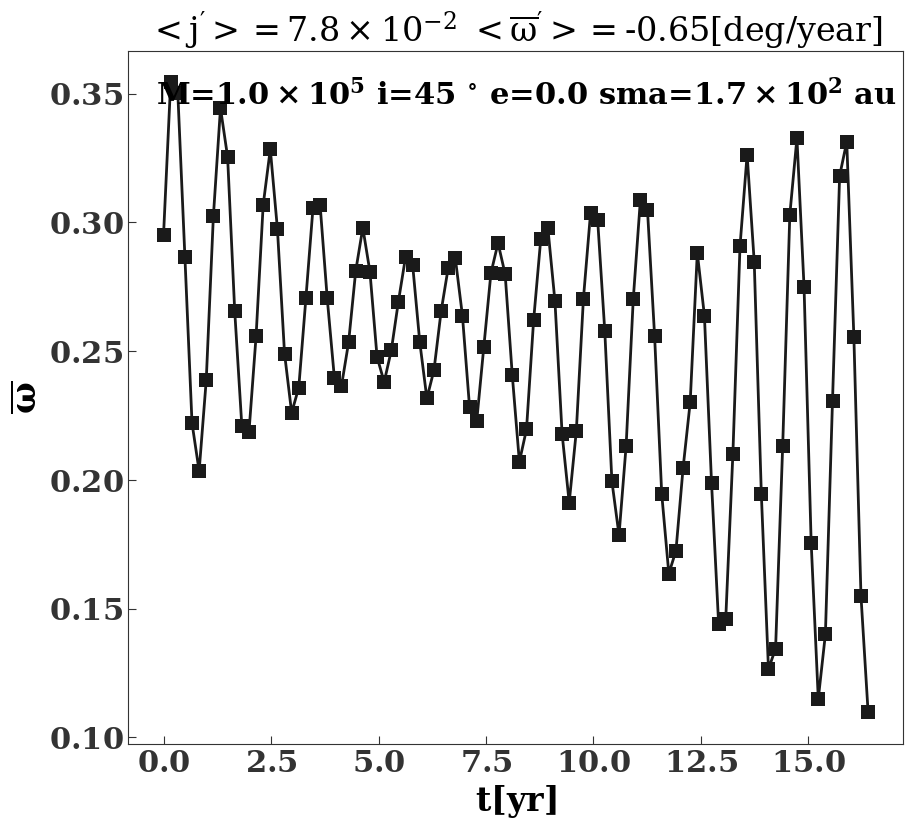

```python
%pylab inline
import numpy as np
import rebound
import reboundx
import cgs_const as cgs

from bash_command import bash_command as bc
import sys
from latex_exp import latex_exp

mm=1.0e5
inc=np.pi/4.
aa=170.*cgs.au/cgs.pc
ecc=0.
a1=1020*cgs.au/cgs.pc
P1=2.*np.pi*(a1)**1.5/(4.0e6)**0.5
e1=0.88


sim=rebound.Simulation()
rebx = reboundx.Extras(sim)
gr=rebx.add("gr")
gr.params["c"]=4571304.57795483
sim.move_to_com()

sim.G=1.0
sim.add(m=4e6)
sim.add(m=mm, a=aa, e=ecc, inc=inc, Omega=inc, M=np.random.uniform(0., 2.*np.pi), primary=sim.particles[0])
sim.add(a=a1, e=e1, pomega=np.random.uniform(0., 2.*np.pi), M=np.random.uniform(0., 2.*np.pi), primary=sim.particles[0])

with open('s2_check', 'w') as ff:
    for i in range(100):
        sim.move_to_com()
        orbs=sim.calculate_orbits(primary=sim.particles[0])
        oo=orbs[-1]
        j=np.cross(sim.particles[2].xyz, sim.particles[2].vxyz)
        j=j/np.linalg.norm(j)
        ff.write('{0} {1} {2} {3} {4} {5} {6}\n'.format(oo.a, oo.e, oo.inc, oo.Omega, oo.omega, oo.M, np.arccos(np.dot(j, [0,0,1])), oo.pomega))
        sim.integrate(sim.t+0.01*P1)

s2_dat=np.genfromtxt('s2_check')
# po_dat=s2_dat[:,4]+s2_dat[:,3]+2.*np.pi
# po_dat2=np.array([pp if pp<2.*np.pi else pp-2.*np.pi for pp in po_dat])
po_dat=fmod(s2_dat[:,4]+s2_dat[:,3]+2.*np.pi, 2.*np.pi)
j_dat=s2_dat[:,-1]

fig,ax=plt.subplots(figsize=(10,9))
ts=np.linspace(0,1,100)*P1*1.5e7
ax.plot(ts, fmod(s2_dat[:,4]+s2_dat[:,3]+2.*np.pi, 2.*np.pi), 's-')
ax.set_ylabel(r"$\overline{\omega}$")
ax.set_xlabel(r"$t [yr]$")

t1=r"$<j'> =$"+"{0}".format(latex_exp.latex_exp((j_dat[-1]-j_dat[0])*180./np.pi/(P1*1.5e7)))
t2=r"$<\overline{\omega}'>=$"+"{0}".format(latex_exp.latex_exp((po_dat[-1]-po_dat[0])*180./np.pi/(P1*1.5e7)))+r"$[deg/year]$"
ax.set_title(t1+" "+t2)
ax.legend(loc='upper left',\
          title="M={0} i={1} e={2} sma={3} au".format(latex_exp.latex_exp(mm), "{0:1.0f}".format(inc*180./np.pi)+r" $^{\circ}$", ecc,\
                                                      latex_exp.latex_exp(aa*cgs.pc/cgs.au)))
```

```
No handles with labels found to put in legend.
```

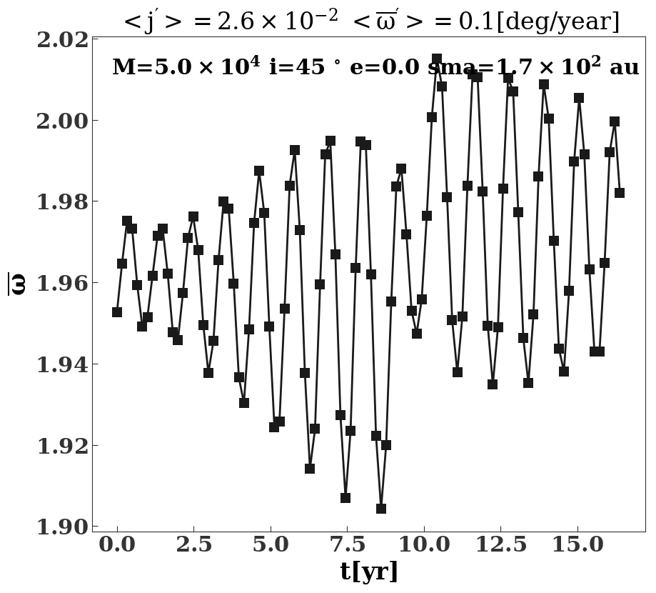

```python
%pylab inline
import numpy as np
import rebound
import reboundx
import cgs_const as cgs

from bash_command import bash_command as bc
import sys
from latex_exp import latex_exp

mm=5e4
inc=np.pi/4.
aa=170.*cgs.au/cgs.pc
ecc=0.
a1=1020*cgs.au/cgs.pc
P1=2.*np.pi*(a1)**1.5/(4.0e6)**0.5
e1=0.88


sim=rebound.Simulation()
rebx = reboundx.Extras(sim)
gr=rebx.add("gr")
gr.params["c"]=4571304.57795483
sim.move_to_com()

sim.G=1.0
sim.add(m=4e6)
sim.add(m=mm, a=aa, e=ecc, inc=inc, Omega=inc, M=np.random.uniform(0., 2.*np.pi), primary=sim.particles[0])
sim.add(a=a1, e=e1, pomega=np.random.uniform(0., 2.*np.pi), M=np.random.uniform(0., 2.*np.pi), primary=sim.particles[0])

with open('s2_check', 'w') as ff:
    for i in range(100):
        sim.move_to_com()
        orbs=sim.calculate_orbits(primary=sim.particles[0])
        oo=orbs[-1]
        j=np.cross(sim.particles[2].xyz, sim.particles[2].vxyz)
        j=j/np.linalg.norm(j)
        ff.write('{0} {1} {2} {3} {4} {5} {6}\n'.format(oo.a, oo.e, oo.inc, oo.Omega, oo.omega, oo.M, np.arccos(np.dot(j, [0,0,1]))))
        sim.integrate(sim.t+0.01*P1)

s2_dat=np.genfromtxt('s2_check')
po_dat=fmod(s2_dat[:,4]+s2_dat[:,3]+2.*np.pi, 2.*np.pi)
j_dat=s2_dat[:,-1]

fig,ax=plt.subplots(figsize=(10,9))
ts=np.linspace(0,1,100)*P1*1.5e7
ax.plot(ts, fmod(s2_dat[:,4]+s2_dat[:,3]+2.*np.pi, 2.*np.pi), 's-')
ax.set_ylabel(r"$\overline{\omega}$")
ax.set_xlabel(r"$t [yr]$")

t1=r"$<j'> =$"+"{0}".format(latex_exp.latex_exp((j_dat[-1]-j_dat[0])*180./np.pi/(P1*1.5e7)))
t2=r"$<\overline{\omega}'>=$"+"{0}".format(latex_exp.latex_exp((po_dat[-1]-po_dat[0])*180./np.pi/(P1*1.5e7)))+r"$[deg/year]$"
ax.set_title(t1+" "+t2)
ax.legend(loc='upper left',\
          title="M={0} i={1} e={2} sma={3} au".format(latex_exp.latex_exp(mm), "{0:1.0f}".format(inc*180./np.pi)+r" $^{\circ}$", ecc,\
                                                      latex_exp.latex_exp(aa*cgs.pc/cgs.au)))
```